# Final Report

Student ID 2935413

2023-12-13

# Descriptives

## Demographics

4300 people participated in total, with 1158 starting the sensation seeking questionnaire, 1660 starting the state anxiety questionnaire, and 4156 starting the trait anxiety questionnaire. After excluding participants who did not start all 3 questionnaires, there were 550 people left for analyses. 453 of these participants completed all 3 questionnaires.

Table 1: Summary statistics of state anxiety, trait anxiety, and sensation seeking scores for each group.

| Group | Condition | State Anxiety N | State Anxiety Mean | State Anxiety S.D | Trait Anxiety N | Trait Anxiety Mean | Trait Anxiety S.D | Sensation Seeking N | Sensation Seeking Mean | Sensation Seeking S.D |
| --- | --- | --- | --- | --- | --- | --- | --- | --- | --- | --- |
| A | control | 105 | 39.12 | 11.42 | 104 | 43.22 | 10.59 | 113 | 6.88 | 2.97 |
| A | experimental | 145 | 38.01 | 9.43 | 135 | 43.47 | 10.39 | 148 | 7.50 | 2.28 |
| B | control | 134 | 37.87 | 10.81 | 135 | 41.05 | 9.72 | 137 | 6.91 | 2.64 |
| B | experimental | 121 | 37.74 | 9.60 | 127 | 41.77 | 9.24 | 131 | 6.98 | 2.33 |

## Score Distributions

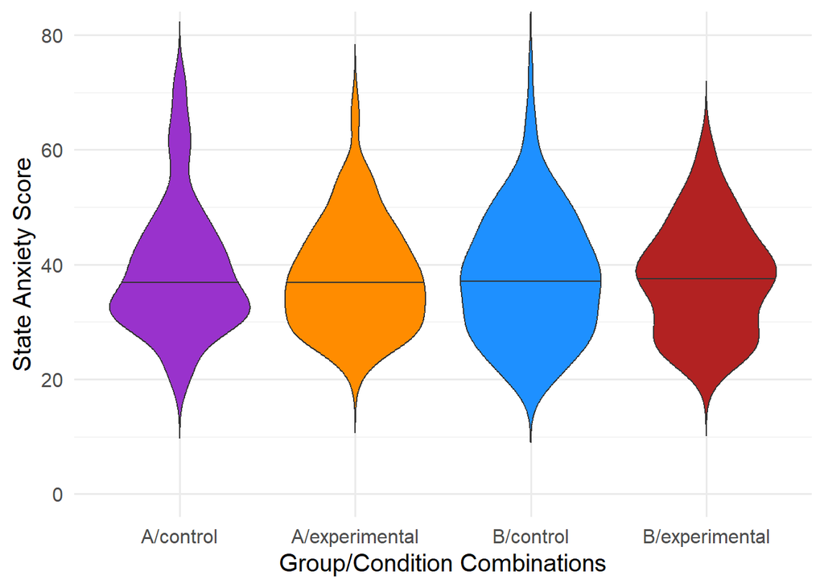

Figure 1: Distribution of state anxiety score for each group/ condition combination.

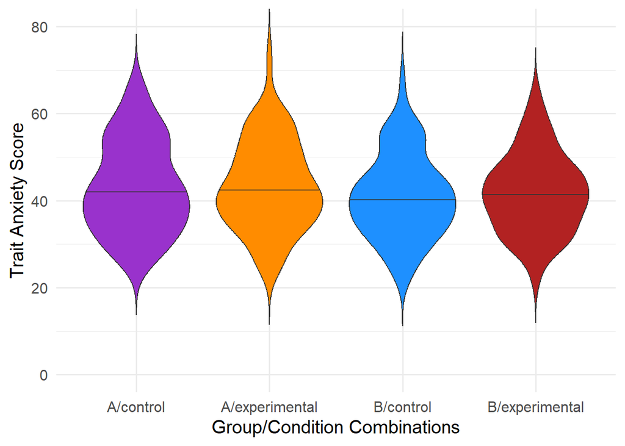

Figure 2: Distribution of trait anxiety score for each group/ condition combination.

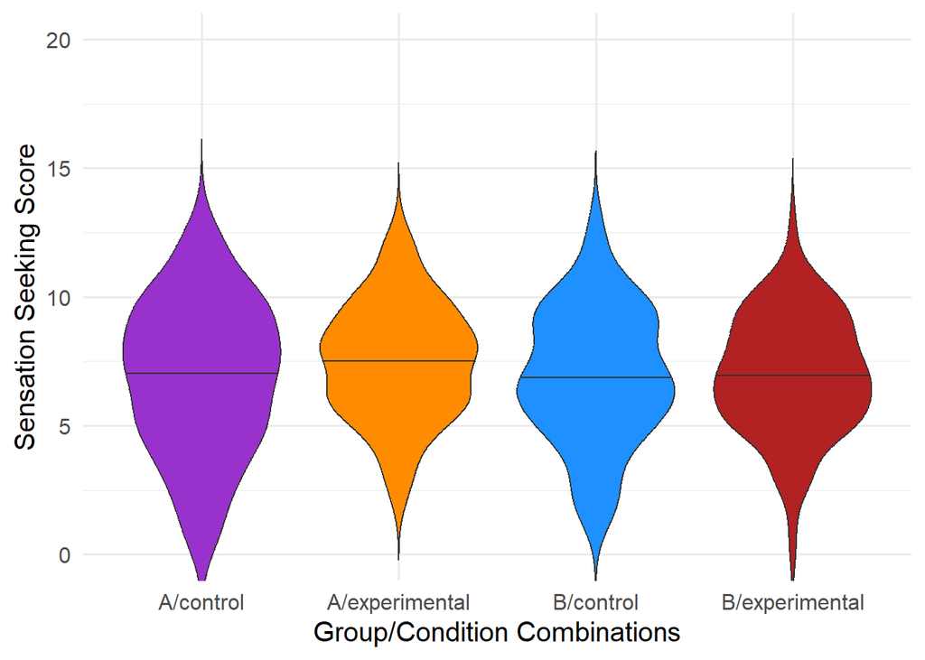

Figure 3: Distribution of sensation seeking score for each group/ condition combination.

# Analysis

## Correlation

Figure 4 shows the correlation between state and trait anxiety scores for group A/ control condition combination. According to the Pearson’s correlation test, state and trait anxiety were positively correlated: $r_{93}$ = 0.68, p < 0.001, 95% CI = [0.55, 0.77].

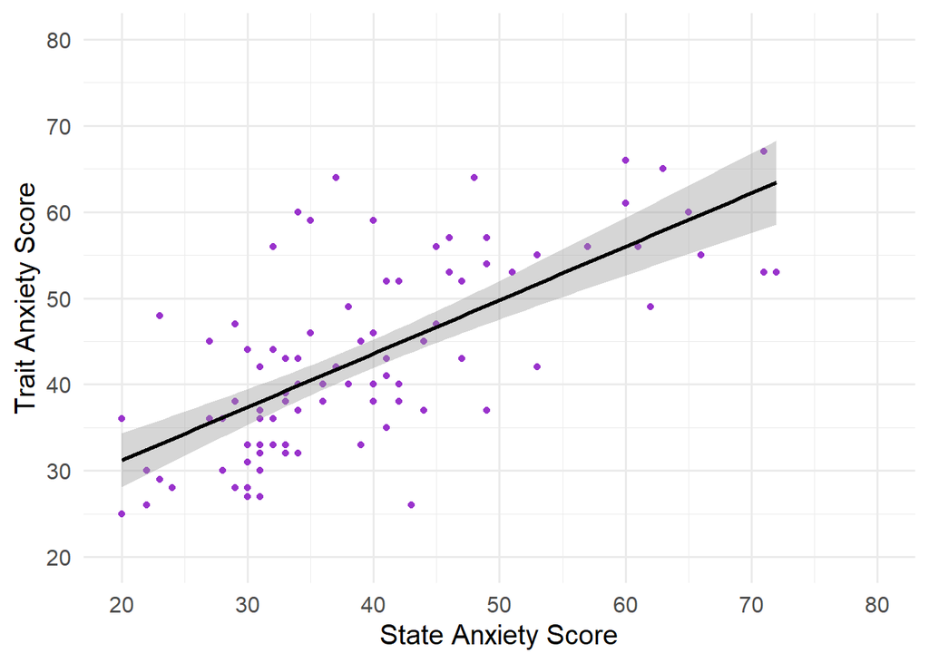

Figure 4: The relationship between state and trait anxiety scores for Group A/ control condition.

## Statistical Power

The statistical power of the correlation test when alpha = 0.01 is 1, which means that the probability of rejecting the null hypothesis (i.e. no correlation exists between state and trait anxiety scores) when it is false is 100%. In other words, the likelihood of successfully detecting a correlation between state and trait anxiety scores when it is actually present is 100%.

In the power simulation, the parameters used were:

1. number of participants = 120,
2. correlation coefficient = 0.68 as the effect size,
3. alpha = 0.01,
4. means of variable x = 39.12 and variable y = 43.22,
5. standard deviations of variable x = 11.42 and variable y = 10.59.

# References

DeBruine, L. (2023). *Faux: Simulation for factorial designs*. Zenodo. https://doi.org/10.5281/zenodo.2669586

Spielberger, C. D. (2012). *State-Trait Anxiety Inventory for Adults*. https://doi.org/10.1037/t06496-000

Wickham, H., Averick, M., Bryan, J., Chang, W., McGowan, L., François, R., Grolemund, G., Hayes, A., Henry, L., Hester, J., Kuhn, M., Pedersen, T., Miller, E., Bache, S., Müller, K., Ooms, J., Robinson, D., Seidel, D., Spinu, V., … Yutani, H. (2019). Welcome to the Tidyverse. *Journal of Open Source Software*, *4*(43), 1686. https://doi.org/10.21105/joss.01686

Zhu, H. (2021). *kableExtra: Construct complex table with ’kable’ and pipe syntax*. https://CRAN.R-project.org/package=kableExtra

Zuckerman, M. (1984). Sensation seeking: A comparative approach to a human trait. *Behavioral and Brain Sciences*, *7*(3), 413–434. https://doi.org/10.1017/S0140525X00018938